# Raw SQL x ORM Benchmarks

*Vojtěch Lengál*

```python
import numpy as np
import pandas as pd
import matplotlib.pyplot as plt


def read_sqlite_data(benchmark_name):
    data = pd.read_csv(f"data/sqlite/DbBenchmarks.{benchmark_name}-report.csv", sep=";")
    return (data.iloc[0], data.iloc[1])


def read_mssql_data(benchmark_name):
    data = pd.read_csv(f"data/mssql/DbBenchmarks.{benchmark_name}-report.csv", sep=";")
    return (data.iloc[0], data.iloc[1])


def get_cell_number(cell):
    return float(cell.split()[0].replace(",", ""))


def get_quantiles(row):
    row_names = ["Min", "Q1", "Median", "Q3", "Max"]
    return (get_cell_number(row[name]) for name in row_names)


def get_unit(row):
    return row["Median"].split()[1]


def render_graph(raw_sql_data, ef_data, split_graphs, title):
    sql_min, sql_q1, sql_med, sql_q3, sql_max = get_quantiles(raw_sql_data)
    ef_min, ef_q1, ef_med, ef_q3, ef_max = get_quantiles(ef_data)
    unit = get_unit(raw_sql_data)

    graph_data = {
        "Raw SQL": [sql_min, sql_max, sql_med, sql_q1, sql_q3],
        "EF Core": [ef_min, ef_max, ef_med, ef_q1, ef_q3],
    }

    if split_graphs:
        # Creating a figure and axes
        fig, axes = plt.subplots(1, 2, figsize=(10, 4))
        raw_sql, ef_core = "Raw SQL", "EF Core"

        # Plotting the first boxplot
        axes[0].boxplot(graph_data[raw_sql], whis=[0, 100])
        axes[0].set_ylabel(f"Duration ({unit})")
        axes[0].set_xticklabels([raw_sql])

        # Plotting the second boxplot
        axes[1].boxplot(graph_data[ef_core], whis=[0, 100])
        axes[1].set_ylabel(f"Duration ({unit})")
        axes[1].set_xticklabels([ef_core])

        # Add common title
        fig.suptitle(title)

        # Adjusting the spacing between subplots
        plt.subplots_adjust(wspace=0.4)

        # Display the plot
        plt.show()
    else:
        # Create a figure and axis
        fig, ax = plt.subplots()

        # Create the boxplot
        ax.boxplot(graph_data.values(), labels=graph_data.keys(), whis=[0, 100])

        # Customize the plot
        ax.set_title(title)
        ax.set_ylabel(f"Duration ({unit})")

        # Show the plot
        plt.show()


def render_benchmark_graphs(
    benchmark_name_raw, benchmark_name_to_display, split_sqlite_graph, split_mssql_graph
):
    sqlite_raw_sql, sqlite_ef = read_sqlite_data(benchmark_name_raw)
    mssql_raw_sql, mssql_ef = read_mssql_data(benchmark_name_raw)

    render_graph(
        sqlite_raw_sql,
        sqlite_ef,
        split_sqlite_graph,
        f"Benchmark: {benchmark_name_to_display} - SQLite",
    )
    render_graph(
        mssql_raw_sql,
        mssql_ef,
        split_mssql_graph,
        f"Benchmark: {benchmark_name_to_display} - SQL Server",
    )
```

## Intro

In this report, we're going to analyze performance overhead of using [EF Core](https://learn.microsoft.com/en-us/ef/) (ORM framework for .NET) compared to raw SQL queries.

We may ask the following questions

- How big is the overhead of using EF Core?
- is this overhead still acceptable in real-world scenarios?

We've set of 8 benchmarks, each of them comparing performance of Raw SQL query to corresponding EF Core query.  
To make it more interesting, we're gonna evaluate benchmarks on 2 DBs

- [SQLite](https://www.sqlite.org/index.html) (embedded DB)
- [SQL Server](https://www.microsoft.com/en-us/sql-server) (classical client-server DB)

### Expected results:

Naturally, I expect raw SQL to be a little bit faster.  
In my opinion, for simple queries, the overhead should be very low, however for more complex one, it can be significant.

For more detailed description, see also *Expectation* sections in individual benchmarks.

## Benchmarks

This section contains a detailed description of benchmarks I executed.

When designing benchmarks, I tried to mimic real-world scenarios.  
All benchmarks execute `GET` operations only; that's because other operations, such as adding, updating or deleting

- typically involve just a single entity, so the query itself shouldn't take a long time and therefore it's not a bottleneck
- and also don't happen as often as GETs

Furthermore, when selecting data in real-world app, we often don't just select all of them, but rather use some kind of a pagination. That's also represented in benchmarks - they often select just the first 1000 results.

As mentioned before, all of the benchmarks compare the performance of raw SQL and EF Core query.  
To show it with an example, we can compare those queries:

- SQL: `SELECT * FROM Products LIMIT 1000`
- EF Core: `dbContext.Products.Take(1000).ToList();`

You can see the individual queries as a code here:

- raw SQL
- EF Core. Note that I'm using default settings - i.e. **Eager loading**

Also note that all methods return objects, so in case of raw SQL, we execute the mapping from rows to objects manually (it's also included in a benchmark). This should also represent a real-world scenario, because in other layers of our app, we typically want to work with objects, not raw DB data.

It's also important to mention that each of the benchmarks is evaluated on both of the following databases:

- SQLite
- SQL Server, running locally in a Docker container (this one is more likely the real-world scenario)

### Testing data

First of all, here's a quick description of the testing data that I use for benchmarking.

Our data model represents a simple e-shop with the following entities:

- Category
- Product
- Order
- Customer

Here's a UML model of our data:

[figure not shown]

You can see, that we have (intentionally) both one-to-many and many-to-many relations.

I generated the test data, i.e.

- 1,000 Categories
- 1,000,000 Products
- 100,000 Orders (each order has <= 10 products)
- 1,000 Customers

using Bogus library.

I intentionally made the testing dataset so large (million products), in order to analyze ORM behaviour on tables of these size.

So, all of the following benchmarks are ran on these data.

### Evaluation

As already mentioned, there are 8 benchmarks, which you can see here.

For measuring results, I used [BenchmarkDotNet library](https://benchmarkdotnet.org/), which makes benchmarking quite simple - you just annotate the selected methods as benchmarks, and then just run the app. The library then does all of the neccessary stuff, like selecting the appropriate number warm-up iterations, method invocations, etc.

> A lot of hand-written benchmarks produce wrong numbers that lead to incorrect business decisions. BenchmarkDotNet protects you from most of the benchmarking pitfalls and allows achieving high measurement precision. You shouldn't worry about the perfect number of method invocation, the number of warm-up and actual iterations: BenchmarkDotNet tries to choose the best benchmarking parameters and achieve a good trade-off between the measurement prevision and the total duration of all benchmark runs. So, you shouldn't use any magic numbers (like "We should perform 100 iterations here"), the library will do it for you based on the values of statistical metrics.

(source: https://benchmarkdotnet.org/#reliability)

The output of a single benchmark is then just a simple CSV file with 2 lines (one for raw SQL query, one for EF Core) containing all of the statistics like

- min. duration
- average duration
- median duration
- etc.

All of the results are stored in data folder.

(note that all of the data come from actual method invocations, so the warm-up data are excluded)

#### Graphs

Benchmark results in this report are displayed using 2 boxplot graphs (one for each DB), comparing the duration of raw SQL and EF Core query.

**It's important to mention the boxplot properties:**

- the whiskers represent min and max durations (excluding warm-up iterations)
- the box borders represent first and third quartile (25th - 75th percentile)
- the colored horizontal line denotes a median

### Consistency

It's also important to mention benchmark consistency.  
I tried to run all of the benchmarks multiple times, and the results were very similar, so from this point of view, we can say that all benchmarks are consistent.

### Get top 1000 products

This benchmark measures a query that selects the first 1000 products (there are no joins) and returns them in a `List`. I'd say this correspondes to real-world scenarios quite well, because we typically have some kind of pagination in our app (i.e. we typically don't select all entities of a given type).

The raw SQL query thus looks like this: `SELECT * FROM Products LIMIT 1000`, while EF Core query is simply: `dbContext.Products.Take(1000).ToList()`

#### Expectation

I expected raw SQL queries to be a little bit faster, which is natural, because ORM under the hood converts queries to SQL and furthermore adds some extra overhead.  
But in this case, the overhead of using ORM shouldn't be significant, maybe just mapping rows to objects, which is done using reflection can take a non-trivial amount of time.

#### Results

Here are the results for both SQLite and SQL Server DBs (note that for SQLite, the results are in `μs`).

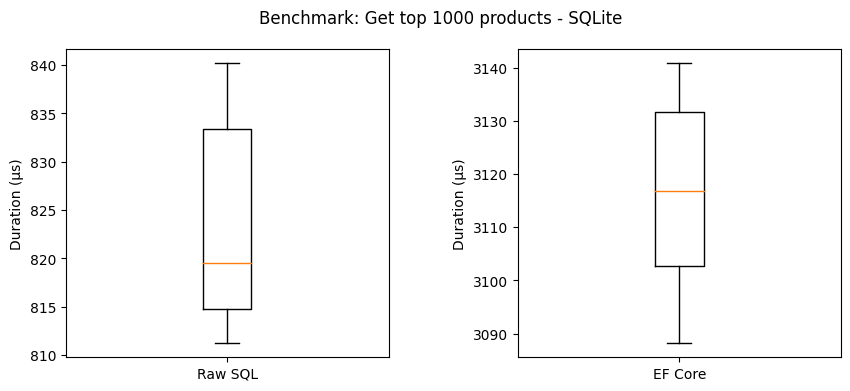

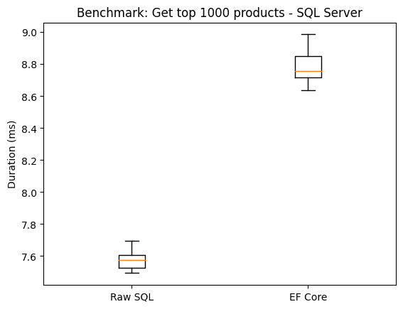

```python
benchmark_name_raw = "GetTop1000ProductsBenchmark"

render_benchmark_graphs(benchmark_name_raw, "Get top 1000 products", True, False)
```

#### Conclusions

First of all, we can see that raw SQL queries are about 10 times faster using SQLite compared to SQL Server. I expected SQLite to be faster, however the difference is suprisingly big in my opinion. The main reason is probably that SQLite is an embedded DB, unlike SQL Server. Therefore, the connection overhead is lower.

The results also show us that for SQL Server, the overhead of using EF Core is quite low (just about 15%).

However, for SQLite, raw SQL are about 4 times faster.  
This difference seems surprisingly big.  
One of the possible explanations is again the previously mentioned lower connection overhead, therefore the query execution time itself has much bigger impact on the final result.

Also note, that I checked the generated SQL, and it looks the same as our raw SQL query.

### Get product by ID

This benchmark simply measures how long it takes to select a product by its ID, which is a primary key. (Also note that, for each query the ID is randomly generated in order to avoid caching of results)

#### Expectation

Again, I expected raw SQL to be a little bit faster. It's also important to mention 2 additional notes

- Compared to previous benchmark, this one selects just 1 product, so the overhead of mapping in EF Core doesn't add up
- On the other hand, the query processing and creation itself (which is done by ORM) has bigger impact on final result

So, it's hard to guess which of these things prevails.

#### Results

Here are the results:

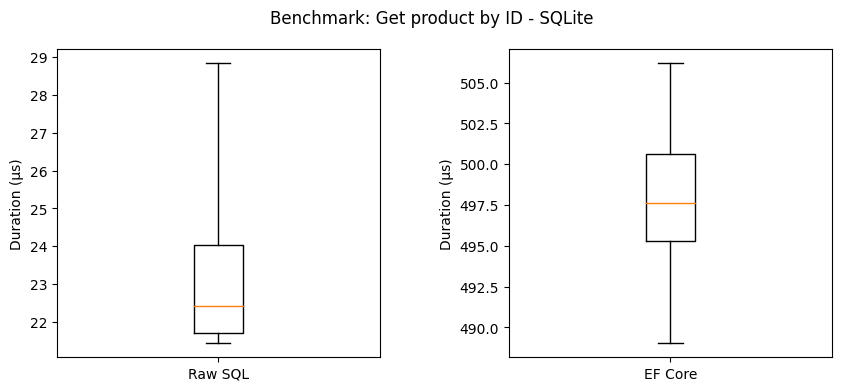

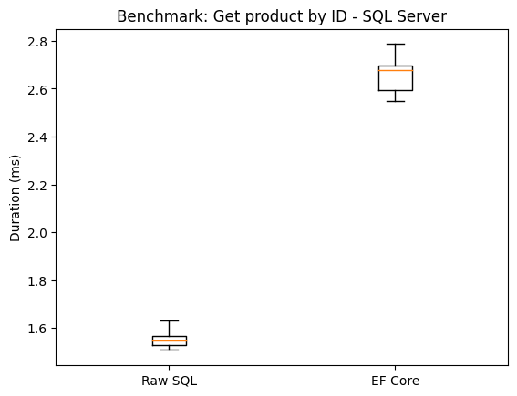

```python
benchmark_name_raw = "GetProductByIdBenchmark"

render_benchmark_graphs(benchmark_name_raw, "Get product by ID", True, False)
```

#### Conclusions

Again, we see that SQLite queries are much faster than SQL Server one.

When it comes to ORM overhead, for SQLite, the raw SQL query is about 20 times faster.  
Similarly to previous benchmark, in SQL Server, the overhead of EF Core is much lower, this time about 70%.

We clearly see, that the difference is much bigger here than in previous benchmark, so I guess this overhead is most likely caused by the query processing and SQL generation, done by EF Core.  
Nevertheless, it's also important to mention that IMO selecting entities by their IDs is typically not a bottleneck in applications.

### Get cheap products

This benchmark measures a query selecting all products, whose price is at most `10` ordered by `Name`.

The raw SQL query is thus a `SELECT` with `WHERE` clause. It's important to mention, that `Price` column is not indexed, so the query has to iterate over all rows.

#### Expectation

My expectations were very similar as in the first benchmark - raw SQL queries should be a little bit faster.

#### Results

Here are the results for both SQLite and SQL Server DBs.

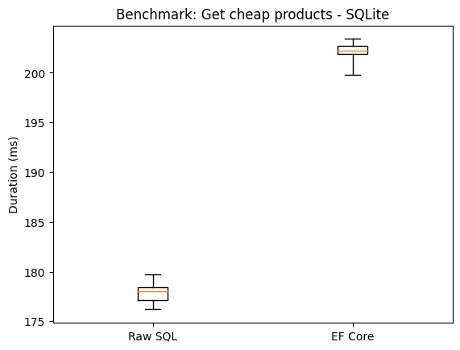

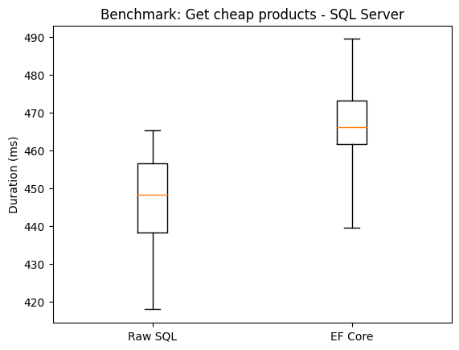

```python
benchmark_name_raw = "GetCheapProductsBenchmark"

render_benchmark_graphs(benchmark_name_raw, "Get cheap products", False, False)
```

#### Conclusions

Compared to previous benchmarks, the results are very different.

The overhead of ORM is much lower

- about 15% for SQLite
- and for SQL Server just under 5%

So, it really seems that based on these 3 benchmarks, we can formulate a hypothesis that says:

> The more rows a query has to proceess, the lower ORM overhead is.

### Get count of cheap products

This benchmark measures is quite similar to previous one. The only difference is that the query selects just count of products whose price is <= 10, instead of the product data.

So, the SQL query is simply a `SELECT COUNT(*)` with `WHERE` clause.

#### Expectation

In this case, I expected smaller overhead than in previous case. That's simply because the result is not a collection of entities (so there's no need for mapping rows to objects), rather an integer.

#### Results

See the results below:

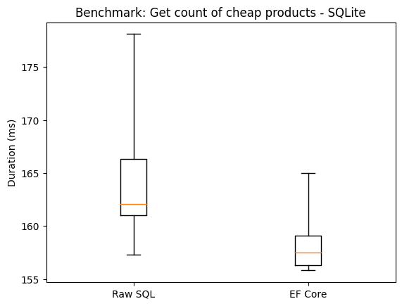

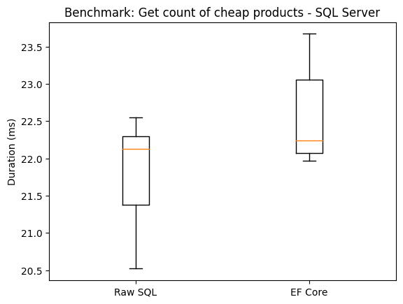

```python
benchmark_name_raw = "GetCountOfCheapProductsBenchmark"

render_benchmark_graphs(benchmark_name_raw, "Get count of cheap products", False, False)
```

First of all, the results for SQL Server are as expected - there's a very small overhead.

For SQLite, EF Core queries were on average even faster than raw SQL, which is quite surprising.  
As I mentioned before, I tried to run all benchmarks multiple times to check consistency and truly in most cases, EF Core was faster here.  
Therefore, I don't think it's just a noise, actually I suspect that there's some form of caching done in EF Core.

It's also interesting how fast the query in SQL Server is (compare the duration with SQLite and previous benchmark - these time SQLite queries are ~ 8 times slower), the possible explanation is that SQL Server is well optimized for `COUNT` queries.

### Get minimal product price

This benchmark measures a query that selects minimal product price (which is returned as a number).

The raw SQL query is very simple: `SELECT MIN(Price) FROM Products`

#### Expectation

Same as in the previous benchmark.

#### Results

Here are the results:

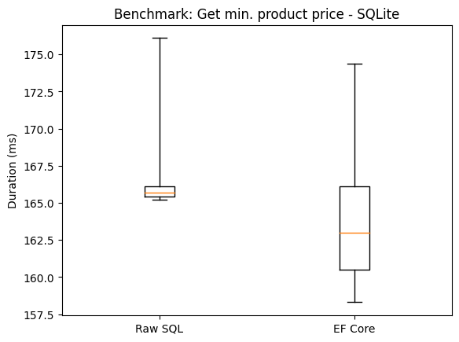

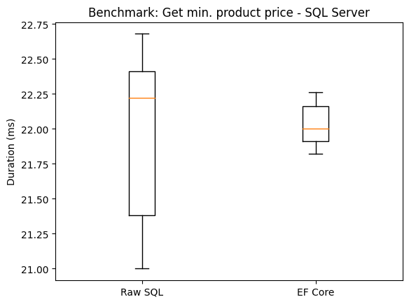

```python
benchmark_name_raw = "GetMinProductPriceBenchmark"

render_benchmark_graphs(benchmark_name_raw, "Get min. product price", False, False)
```

#### Conclusions

We can see, that the results are very similar to previous benchmark, which was expected.

Again, in SQLite using EF Core is even faster than raw SQL.  
For SQL Server, the results are very similar, on average raw SQL query is little bit faster, on the other hand if we evaluate it using medians it's slower.

The only possible explanation that comes to my mind is the previously mentioned caching in ORM.

### Get top 1000 product names

This benchmark measures a query selecting first 1000 product names.  
Note that this benchmark is similar to the first one, however the query selects only product names, instead of all columns.

#### Expectation

Compared to first benchmark, there's no need to map the rows into objects by ORM, so from this point of view, the overhead should be lower.

#### Results

See the results below:

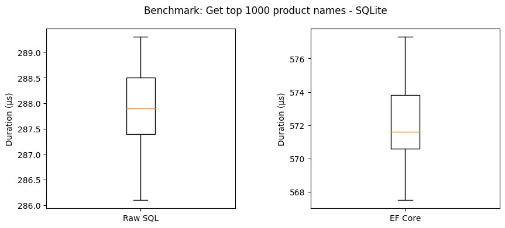

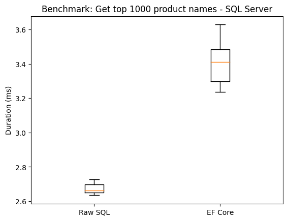

```python
benchmark_name_raw = "GetTop1000ProductNamesBenchmark"

render_benchmark_graphs(benchmark_name_raw, "Get top 1000 product names", True, False)
```

#### Conclusions

We see that for SQLite, the overhead is indeed lower than in the 1st benchmark (now EF Core query is about 2x slower).

However, for SQL Server, the overhead is now slightly higher (~ 25 % compared to 15 % in 1st benchmark).  
In my opinion, this overhead is caused mostly by parsing and generating SQL query.

### Get top 1000 products with categories

The aim of this benchmark is to evaluate performance on a query containing a single `JOIN` statement.  
The query selects top 1000 products and join the categories, so the result is a list of products with references to categories (and respectively each category has references to products contained).

Note that when using raw SQL queries, we need to create the references manually, while in EF Core it's done simply by calling `.Include(p => p.Category)`.

#### Expectation

Compared to 1st benchmark, there's a `JOIN` added. The query is therefore a little bit more complex, however I think it shouldn't be hard for ORM to translate it into effective SQL. However, the mapping rows -> objects is more complex, therefore it can be a possible place for extra overhead.

#### Results

The results are below:

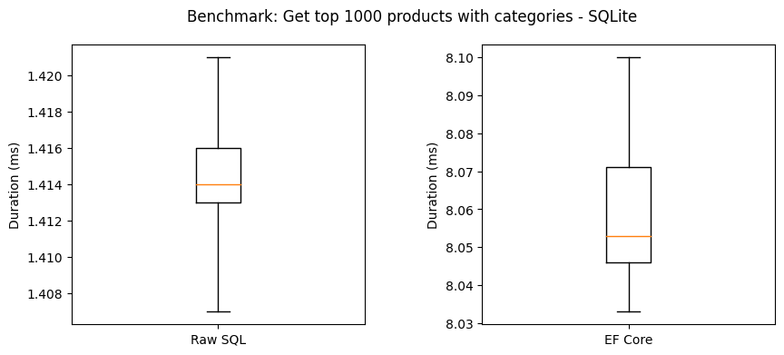

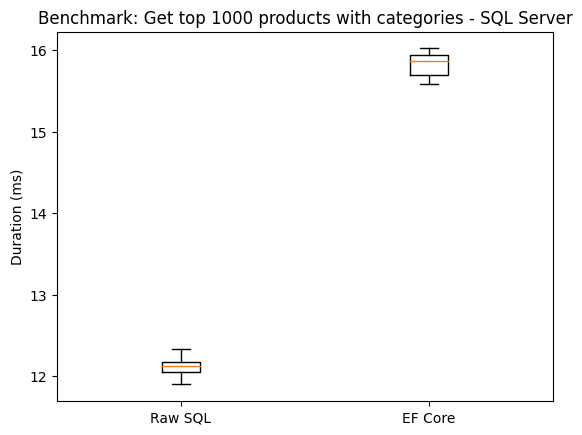

```python
benchmark_name_raw = "GetTop1000ProductsWithCategories"

render_benchmark_graphs(benchmark_name_raw, "Get top 1000 products with categories", True, False)
```

#### Conclusions

We can see that the EF Core query is over 5 times slower when using SQLite, which is actually a little bit more overhead than in the 1st benchmark.  
When using SQL Server, the overhead is about 30%.

We can cleary see that the overhead is bigger than in 1st benchmark (where we didn't `JOIN` Category table).

Again, there are in my opinion two main places where overhead can happen:

- translating EF Core query to SQL
- mapping resulting rows to objects

### Get top 1000 Orders with all entities loaded

Finally, the last benchmark measures the most complex query.

In this case we select the first 1000 orders and use multiple joins. We firstly join `Products` table (note that this is a many-to-many relation, so in fact there are 2 joins) and then `Categories` to the individual products; furthermore we also join `Customers` table.

The raw SQL query therefore contains 4 JOINS.

#### Expectation

I expected this benchmark to be the most challenging for ORM, because the final query is by far the most complex one.

#### Results

Here are the results for both SQLite and SQL Server DBs.

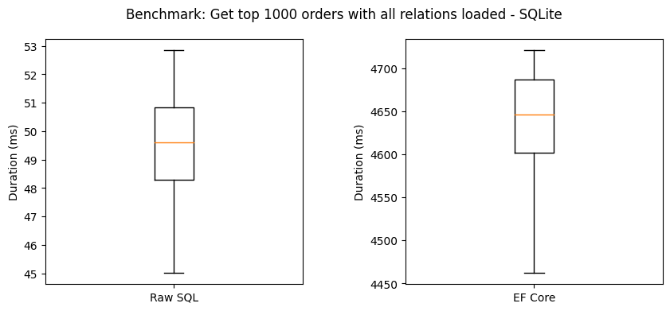

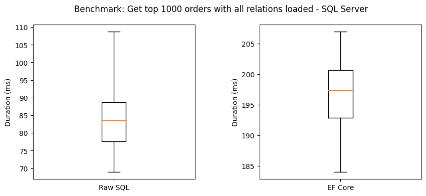

```python
benchmark_name_raw = "GetTop1000OrdersWithAllEntitiesLoadedBenchmark"

render_benchmark_graphs(benchmark_name_raw, "Get top 1000 orders with all relations loaded", True, True)
```

#### Conclusions

We see that the overhead is indeed quite big in this case.

For SQL Server, the raw SQL query is about 2.5 times faster than using EF Core, which is still in the expected range.

On the other hand, when using SQLite the overhead is extreme.  
The EF Core query is almost 100 times slower, and it takes almost 5 seconds to complete, meaning that for real-world scenarios it's simply too slow and therefore useless.

This surprised me a lot, and honestly I have no idea what causes such a huge overhead (it's also interesting that for SQL Server, the overhead is much smaller).  
This doesn't seem to be just translating EF Core query to SQL and row -> object mapping, there is probably something else going on that takes so much time.

Then, I tried to analyze the generated SQL queries, which for SQLite looks as follows (for SQL Server it's analogical)

```
DECLARE @__p_0 int = 1000;

SELECT "t"."Id", "t"."CustomerId", "t"."Status", "c"."Id", "c"."Email", "c"."FullName", "t0"."OrdersId", "t0"."ProductsId", "t0"."Id", "t0"."CategoryId", "t0"."Description", "t0"."Name", "t0"."Price", "t0"."Id0", "t0"."Name0"
FROM (
    SELECT "o"."Id", "o"."CustomerId", "o"."Status"
    FROM "Orders" AS "o"
    LIMIT @__p_0
) AS "t"
INNER JOIN "Customers" AS "c" ON "t"."CustomerId" = "c"."Id"
LEFT JOIN (
    SELECT "o0"."OrdersId", "o0"."ProductsId", "p"."Id", "p"."CategoryId", "p"."Description", "p"."Name", "p"."Price", "c0"."Id" AS "Id0", "c0"."Name" AS "Name0"
    FROM "OrderProduct" AS "o0"
    INNER JOIN "Products" AS "p" ON "o0"."ProductsId" = "p"."Id"
    INNER JOIN "Categories" AS "c0" ON "p"."CategoryId" = "c0"."Id"
) AS "t0" ON "t"."Id" = "t0"."OrdersId"
ORDER BY "t"."Id", "c"."Id", "t0"."OrdersId", "t0"."ProductsId", "t0"."Id"
```

The EF Core query looks like this:

```
dbContext.Orders.Take(1000)
    .Include(o => o.Customer)
    .Include(o => o.Products).ThenInclude(p => p.Category)
    .ToList();
```

On the other hand, the hand-written SQL looks as follows:

```
SELECT o.Status, o.Id as OrderId,
    c.FullName, c.Id AS CustomerId, c.Email,
    p.Id AS ProductId, p.Name AS ProductName, p.Description, p.Price,
    ca.Id AS CategoryId, ca.Name as CategoryName
FROM (
    SELECT * FROM Orders LIMIT 1000
) AS o
INNER JOIN Customers c on c.Id = o.CustomerId
INNER JOIN OrderProduct op on o.Id = op.OrdersId
INNER JOIN Products p on op.ProductsId = p.Id
INNER JOIN Categories ca on ca.Id = p.CategoryId
```

We can see the generated SQL could less effective, mostly for 2 main reasons

- the `SELECT` inside `LEFT JOIN` selects all rows (not just those we need)
- there's useless `ORDER BY` at the end (we didn't need to order anything).

However, the DB engine may optimize the query before executing, so it's hard to say how much overhead it actually brings. Furthermore, as I've mentioned before, the generated query in SQL server is analogical, however the overhead is still quite small. So, I don't think we can blame this just on ineffective query.

## Platform description

All of the data were collected on my laptop, which has the following specification:

- Windows 11
- CPU: AMD Ryzen 7 5700U with Radeon Graphics
- .NET 7.0

Package versions:

- Microsoft.EntityFrameworkCore 7.0.7
- Microsoft.Data.Sqlite 7.0.7
- System.Data.SqlClient 4.8.5

## Build & run

Prerequisites:

- .NET 7
- Docker Compose / local instance of SQL Server

Run

```
docker compose up
```

to start SQL Server DB in a container (`localhost:5555`)

Run

```
dotnet run --project DbBenchmarks
```

to run the benchmarks.  
In order to select DB, set the corresponding value on line 12 in Benchmarks file.

To generate test data, uncomment the corresponding lines in Program class and run the same command.

## Final conclusions

We see that there's definitely some overhead when using EF Core, which seems to be more significant

- if using SQLite - this can be caused by lower connection overhead (simply connection to embedded DB takes less than connecting to classical DB), so the query execution itself has bigger impact on final duration
- if the query uses JOINs, especially if there are multiple ones (just see the last benchmark).  
  Especially, for SQLite the overhead seems to be quite big, so I'd consider using raw SQL or another lower-level ORM (such as Dapper) for these types of queries.  
  For SQL Server, single join overhead is quite small, while EF Core query using multiple JOINS is about 2.5 times slower than raw SQL, however should be still fine.
- if the query is fast (like getting entity by its primary key). On the other hand, it shouldn't be a bottleneck in this case, since the query is fast anyway.

Furthermore, from the graphs, it's clear that the overhead isn't any kind of "constant", typically the more time the query takes, the higher the absolute overhead is, however relative overhead is often lower.

In my opinion, most of the overhead happens in 2 places:

- while parsing EF Core query into SQL
- while mapping resulting rows to objects

Also note that, the generated SQL may not be the most effective (see the last benchmark), however it's hard to estimate the possible overhead, because DB engines typically optimize queries before executing.

For further details, see also: https://learn.microsoft.com/en-us/ef/core/performance/#aspects-of-data-access-performance

I'd say that in most real-world scenarios (that use client/server DB, such as SQL Server), **the ORM overhead is definitely acceptable**. We also should consider the following points:

- using ORM is much more user-friendly and type-safe
- if the DB is on another server, the network latency can be much higher (I'm running the DB locally) and therefore the overhead of ORM would be further diminished

We clearly see that only the last benchmark could be a potential bottleneck. On the other hand, we also need to realise how often in real-world we select thousand entities and join multiple tables...

However, when using SQLite, I'd definitely consider using lower-level ORM / raw SQL for more complex queries with JOINs that involve a lot of data (like the last benchmark).

We can also observe several other interesting details, such as SQL Server seems to be much more optimized for aggregation queries (see the results for queries using `COUNT` and `MIN`).